# TV ads in Georgia Senate Runoffs

Aaron Kessler, Data/Investigations

December 04, 2020

The numbers below reflect the currently available data as of **10:21 AM on Dec. 04**.

### *Totals*

Ads Aired by **Party**

(From Nov. 4th)

| advertiser_party | ads_aired |
| --- | --- |
| Democrat | 51,776 |
| Republican | 43,430 |

Ads Aired by **Candidate/Group**

(From Nov. 4th)

|  | advertiser | ads_aired |
| --- | --- | --- |
| Democrat |  |  |
| GA Senate 2020 General Runoff | Ossoff for GA Senate | 29,662 |
| GA Senate Special 2020 General Runoff | Warnock for GA Senate | 16,326 |
| GA Senate Special 2020 General Runoff | Georgia Honor | 3,380 |
| GA Senate 2020 General Runoff | The Georgia Way | 2,094 |
| GA Senate Special 2020 General Runoff | The Georgia Way | 295 |
| GA Senate Special 2020 General Runoff | Meidas Touch | 15 |
| GA Senate 2020 General Runoff | Meidas Touch | 4 |
| Republican |  |  |
| GA Senate Special 2020 General Runoff | Loeffler for GA Senate | 14,389 |
| GA Senate 2020 General Runoff | Perdue for GA Senate | 14,294 |
| GA Senate Special 2020 General Runoff | American Crossroads | 6,352 |
| GA Senate 2020 General Runoff | Senate Leadership Fund | 4,653 |
| GA Senate Special 2020 General Runoff | NRSC/Loeffler | 2,219 |
| GA Senate Special 2020 General Runoff | NRSC | 413 |
| GA Senate 2020 General Runoff | NRSC | 408 |
| GA Senate 2020 General Runoff | Senate Georgia Battleground Fund/Perdue & Loeffler | 216 |
| GA Senate Special 2020 General Runoff | Senate Georgia Battleground Fund/Perdue & Loeffler | 216 |
| GA Senate 2020 General Runoff | US Chamber of Commerce | 97 |
| GA Senate Special 2020 General Runoff | US Chamber of Commerce | 97 |
| GA Senate 2020 General Runoff | The Lincoln Project | 38 |
| GA Senate Special 2020 General Runoff | The Lincoln Project | 38 |

### *Daily Totals*

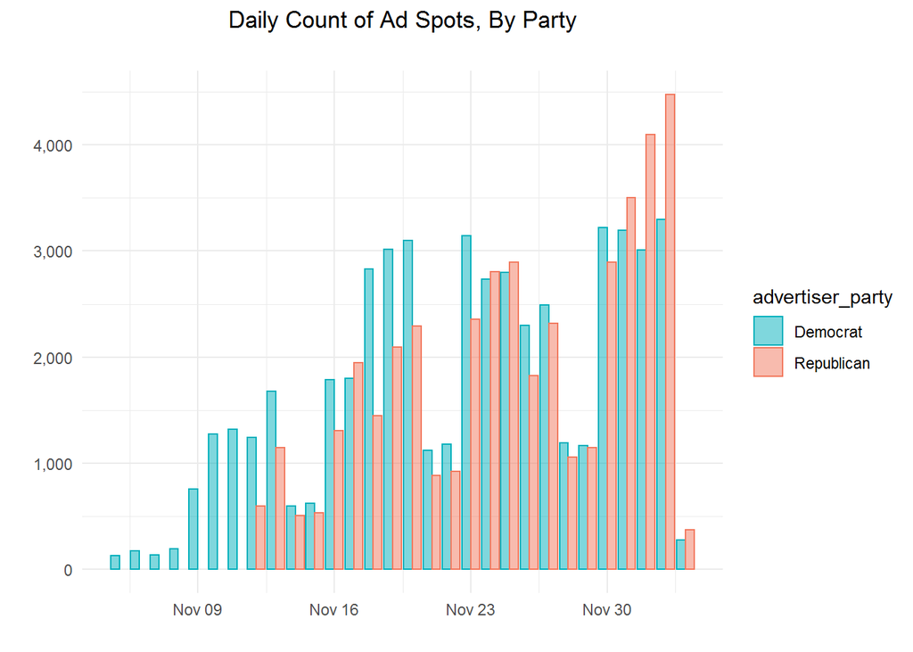

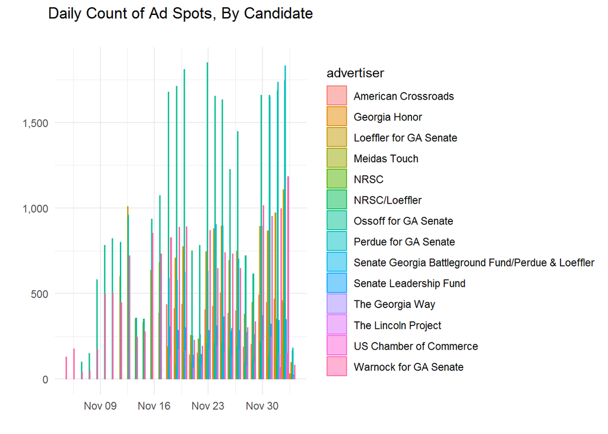

### *Tone*

Ad Tone by **Party**

(From Nov. 4th)

| advertiser_party | tone | ads_aired |
| --- | --- | --- |
| Democrat | Contrast | 17,151 |
| Democrat | Negative | 16,458 |
| Democrat | Positive | 18,167 |
| Republican | Contrast | 76 |
| Republican | Negative | 34,290 |
| Republican | Positive | 9,064 |

Ad Tone by **Candidate/Group**

(From Nov. 4th)

| advertiser | tone | ads_aired |
| --- | --- | --- |
| Democrat |  |  |
| Georgia Honor | Negative | 3,380 |
| Meidas Touch | Contrast | 4 |
| Meidas Touch | Negative | 15 |
| Ossoff for GA Senate | Contrast | 7,652 |
| Ossoff for GA Senate | Negative | 9,204 |
| Ossoff for GA Senate | Positive | 12,806 |
| The Georgia Way | Negative | 2,389 |
| Warnock for GA Senate | Contrast | 9,495 |
| Warnock for GA Senate | Negative | 1,470 |
| Warnock for GA Senate | Positive | 5,361 |
| Republican |  |  |
| American Crossroads | Negative | 6,352 |
| Loeffler for GA Senate | Negative | 11,234 |
| Loeffler for GA Senate | Positive | 3,155 |
| NRSC | Negative | 612 |
| NRSC | Positive | 209 |
| NRSC/Loeffler | Negative | 27 |
| NRSC/Loeffler | Positive | 2,192 |
| Perdue for GA Senate | Negative | 11,412 |
| Perdue for GA Senate | Positive | 2,882 |
| Senate Georgia Battleground Fund/Perdue & Loeffler | Positive | 432 |
| Senate Leadership Fund | Negative | 4,653 |
| The Lincoln Project | Contrast | 76 |
| US Chamber of Commerce | Positive | 194 |

### *Markets*

Top 10 Markets for Ad Airings

(From Nov. 4th)

| market | ads_aired |
| --- | --- |
| Atlanta, GA | 20,163 |
| Savannah, GA | 13,828 |
| Augusta, GA | 12,785 |
| Columbus, GA | 11,627 |
| Macon, GA | 10,032 |
| Albany, GA | 9,227 |
| Chattanooga, TN | 6,133 |
| Tallahassee, FL-Thomasville, GA | 4,104 |
| Jacksonville, FL | 3,639 |
| Greenville-Spartanburg, SC-Asheville, NC | 2,118 |

### *Favorite Shows*

Top Programs for Ad Airings

(From Nov. 4th)

| program_name | ads_aired |
| --- | --- |
| CBS This Morning | 2,865 |
| Family Feud | 2,775 |
| Today | 2,442 |
| Judge Judy | 2,053 |
| Good Morning America | 1,882 |
| Jeopardy! | 1,465 |
| Live With Kelly and Ryan | 1,415 |
| The Big Bang Theory | 1,370 |
| Dr. Phil | 1,252 |
| The Late Show With Stephen Colbert | 1,222 |

# Ad Spending

Ad Analytics also captures data on actual and future ad spending taken from the contracts signed with TV stations. This dataset does not provide the detailed information on airtimes and the nature of the ads themselves, but does allow us to see how much money has been spent on TV advertising so far, as well as the ad buys that have been booked for future days/weeks.

### *Spending to Date*

The numbers below reflect the currently available data on **airtime through today, Dec. 04**.

Ad Spending by **Party**

(through today)

| advertiser_party | spent |
| --- | --- |
| Democrat | $62,057,860 |
| Republican | $57,175,457 |
| Independent | $215,593 |

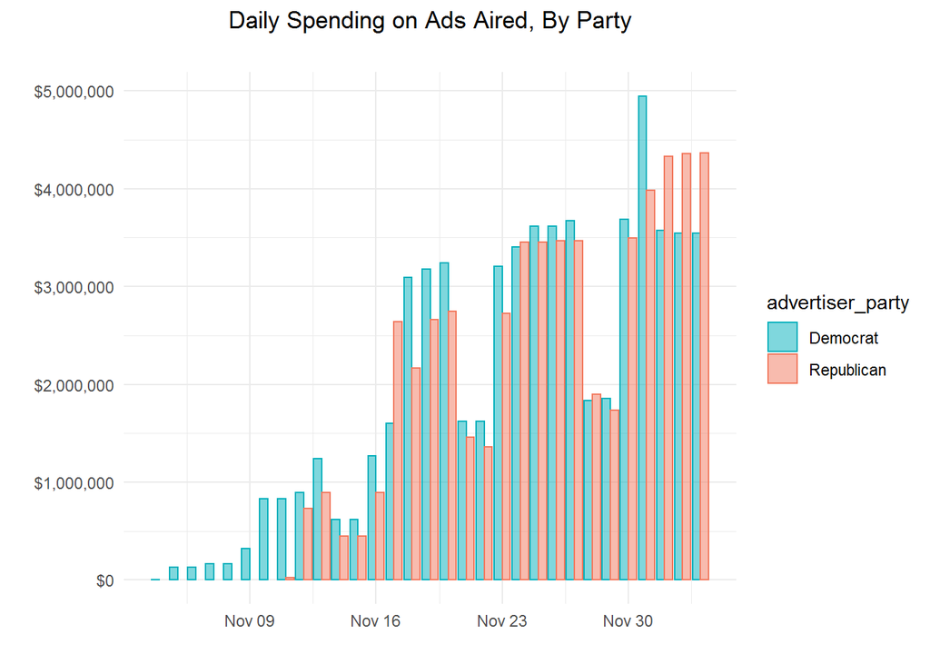

Ad Spending by **Candidate/Group**

(through today)

|  | advertiser | spent |
| --- | --- | --- |
| Democrat |  |  |
| GA Senate Special 2020 General Runoff | Warnock for GA Senate | $24,318,451 |
| GA Senate 2020 General Runoff | Ossoff for GA Senate | $23,475,683 |
| GA Senate Special 2020 General Runoff | Georgia Honor | $7,535,153 |
| GA Senate 2020 General Runoff | The Georgia Way | $6,528,973 |
| GA Senate 2020 General Runoff | Meidas Touch | $100,000 |
| GA Senate Special 2020 General Runoff | Meidas Touch | $99,600 |
| GA Senate 2020 General Runoff | Georgia Honor | $0 |
| Republican |  |  |
| GA Senate Special 2020 General Runoff | Loeffler for GA Senate | $14,942,658 |
| GA Senate Special 2020 General Runoff | American Crossroads | $14,466,494 |
| GA Senate 2020 General Runoff | Senate Leadership Fund | $13,018,517 |
| GA Senate 2020 General Runoff | Perdue for GA Senate | $10,543,596 |
| GA Senate Special 2020 General Runoff | NRSC/Loeffler | $1,704,505 |
| GA Senate 2020 General Runoff | NRSC | $453,360 |
| GA Senate Special 2020 General Runoff | NRSC | $453,360 |
| GA Senate 2020 General Runoff | US Chamber of Commerce | $291,972 |
| GA Senate Special 2020 General Runoff | US Chamber of Commerce | $291,972 |
| GA Senate 2020 General Runoff | Let's Get to Work PAC | $212,789 |
| GA Senate 2020 General Runoff | Americans for Prosperity Action | $190,476 |
| GA Senate Special 2020 General Runoff | Americans for Prosperity Action | $95,238 |
| GA Senate 2020 General Runoff | Senate Georgia Battleground Fund/Perdue & Loeffler | $86,160 |
| GA Senate Special 2020 General Runoff | Senate Georgia Battleground Fund/Perdue & Loeffler | $86,160 |
| GA Senate 2020 General Runoff | The Lincoln Project | $77,755 |
| GA Senate Special 2020 General Runoff | The Lincoln Project | $77,755 |
| GA Senate 2020 General Runoff | Protect Freedom PAC | $53,999 |
| GA Senate Special 2020 General Runoff | Protect Freedom PAC | $53,999 |
| GA Senate 2020 General Runoff | Club for Growth Action | $37,346 |
| GA Senate Special 2020 General Runoff | Club for Growth Action | $37,346 |
| Independent |  |  |
| GA Senate 2020 General Runoff | American Bankers Association | $215,593 |

### *Spending TODAY itself*

The numbers below reflect the currently available data on **airtime bought for today, Dec. 04**.

Ad Spending by **Party**

(Today's Buys Only)

| advertiser_party | spent |
| --- | --- |
| Republican | $4,364,241 |
| Democrat | $3,545,013 |
| Independent | $71,864 |

Ad Spending by **Candidate/Group**

(Today's Buys Only)

|  | advertiser | spent |
| --- | --- | --- |
| Democrat |  |  |
| GA Senate 2020 General Runoff | Ossoff for GA Senate | $1,479,356 |
| GA Senate Special 2020 General Runoff | Warnock for GA Senate | $1,145,710 |
| GA Senate Special 2020 General Runoff | Georgia Honor | $486,202 |
| GA Senate 2020 General Runoff | The Georgia Way | $433,745 |
| Republican |  |  |
| GA Senate 2020 General Runoff | Perdue for GA Senate | $999,091 |
| GA Senate Special 2020 General Runoff | American Crossroads | $960,683 |
| GA Senate Special 2020 General Runoff | Loeffler for GA Senate | $936,686 |
| GA Senate 2020 General Runoff | Senate Leadership Fund | $889,541 |
| GA Senate 2020 General Runoff | NRSC | $151,120 |
| GA Senate Special 2020 General Runoff | NRSC | $151,120 |
| GA Senate 2020 General Runoff | US Chamber of Commerce | $75,781 |
| GA Senate Special 2020 General Runoff | US Chamber of Commerce | $75,781 |
| GA Senate 2020 General Runoff | The Lincoln Project | $28,584 |
| GA Senate Special 2020 General Runoff | The Lincoln Project | $28,584 |
| GA Senate 2020 General Runoff | Protect Freedom PAC | $13,500 |
| GA Senate Special 2020 General Runoff | Protect Freedom PAC | $13,500 |
| GA Senate 2020 General Runoff | Americans for Prosperity Action | $11,905 |
| GA Senate 2020 General Runoff | Let's Get to Work PAC | $7,475 |
| GA Senate 2020 General Runoff | Club for Growth Action | $7,469 |
| GA Senate Special 2020 General Runoff | Club for Growth Action | $7,469 |
| GA Senate Special 2020 General Runoff | Americans for Prosperity Action | $5,952 |
| Independent |  |  |
| GA Senate 2020 General Runoff | American Bankers Association | $71,864 |

### *Future Spending Booked*

The numbers below reflect the currently available data on **airtime booked for after Dec. 04**.

(Note that these are *booking contracts only* and may change, and they frequently do in fast-moving campaigns.)

Future Spending by **Party**

(Contracts Only)

| advertiser_party | to_be_spent |
| --- | --- |
| Republican | $96,577,571 |
| Democrat | $55,628,848 |
| Independent | $467,117 |

Future Spending by **Candidate/Group**

(Contracts Only)

|  | advertiser | to_be_spent |
| --- | --- | --- |
| Democrat |  |  |
| GA Senate Special 2020 General Runoff | Warnock for GA Senate | $27,211,769 |
| GA Senate 2020 General Runoff | Ossoff for GA Senate | $21,941,716 |
| GA Senate 2020 General Runoff | DSCC | $1,554,517 |
| GA Senate Special 2020 General Runoff | DSCC | $1,554,517 |
| GA Senate Special 2020 General Runoff | Georgia Honor | $1,458,605 |
| GA Senate 2020 General Runoff | The Georgia Way | $1,301,235 |
| GA Senate 2020 General Runoff | Future Forward USA Action | $288,277 |
| GA Senate Special 2020 General Runoff | Future Forward USA Action | $288,277 |
| GA Senate 2020 General Runoff | The Principles Project | $14,968 |
| GA Senate Special 2020 General Runoff | The Principles Project | $14,968 |
| Republican |  |  |
| GA Senate Special 2020 General Runoff | American Crossroads | $23,438,721 |
| GA Senate Special 2020 General Runoff | Loeffler for GA Senate | $23,016,597 |
| GA Senate 2020 General Runoff | Senate Leadership Fund | $21,820,022 |
| GA Senate 2020 General Runoff | Perdue for GA Senate | $18,782,437 |
| GA Senate 2020 General Runoff | NRSC | $3,005,459 |
| GA Senate Special 2020 General Runoff | NRSC | $3,005,459 |
| GA Senate 2020 General Runoff | NRA Victory Fund | $557,494 |
| GA Senate Special 2020 General Runoff | NRA Victory Fund | $557,494 |
| GA Senate 2020 General Runoff | US Chamber of Commerce | $387,304 |
| GA Senate Special 2020 General Runoff | US Chamber of Commerce | $387,304 |
| GA Senate Special 2020 General Runoff | Protect Freedom PAC | $375,077 |
| GA Senate 2020 General Runoff | Protect Freedom PAC | $329,300 |
| GA Senate 2020 General Runoff | Americans for Prosperity Action | $273,809 |
| GA Senate 2020 General Runoff | Club for Growth Action | $171,791 |
| GA Senate Special 2020 General Runoff | Club for Growth Action | $171,791 |
| GA Senate Special 2020 General Runoff | Americans for Prosperity Action | $136,905 |
| GA Senate 2020 General Runoff | Let's Get to Work PAC | $52,324 |
| GA Senate 2020 General Runoff | The Lincoln Project | $28,584 |
| GA Senate Special 2020 General Runoff | The Lincoln Project | $28,584 |
| GA Senate 2020 General Runoff | Numbers USA | $25,557 |
| GA Senate Special 2020 General Runoff | Numbers USA | $25,557 |
| Independent |  |  |
| GA Senate 2020 General Runoff | American Bankers Association | $467,117 |